# Introduction to Data Cleaning with the Tidyverse

##### The data.table approach

Thus far, the package ‘data.table’ has not been explored in any depth (and it still won’t be for space considerations). Nevertheless, ‘data.table’ is useful for manipulating large tables; it is extremely efficient (even better than tidyverse functions).

**Reshaping from long to wide:** -we will use the previously created data set “cotton_barley_inner” from inner join of the barley and cotton data sets.

```r
# ID variable needs to be separated into State and year
cotton_barley_inner2 <- separate(cotton_barley_inner, ID, c("State", "Year"), sep = "_")
head(cotton_barley_inner2)
```

```
## # A tibble: 6 x 6
##   State     Year  cotton_acres cotton_yield barley_acres barley_yield
##   <chr>     <chr>        <dbl>        <dbl>        <dbl>        <dbl>
## 1 Tennessee 1866        649000          121         4000           23
## 2 Texas     1866        490000          325         3000           16
## 3 Tennessee 1867        611000          137         4000           19
## 4 Texas     1867        491000          195         2000           20
## 5 Tennessee 1868        520000          170         4000           18
## 6 Texas     1868        581000          197         2000           22
```

Reshape cotton acreage, using State as the ID variable:

```r
cotton_acres_wide <- dcast(setDT(cotton_barley_inner2), State ~ Year, value.var = "cotton_acres")
```

**Reshaping with multiple variables**

Multiple ID variables can be specified on the left side of the tilde and/or multiple column categories can be specified on right side. Furthermore, multiple columns (the “value.var”) can be specified to fill the cells.

Reshape cotton acreage, using State as the ID variable using both cotton acres and cotton yield to fill the cells:

```r
cotton_wide <- dcast(setDT(cotton_barley_inner2), State ~ Year, value.var = c("cotton_acres", "cotton_yield"))

sample(colnames(cotton_wide), 30)
```

```
##  [1] "cotton_yield_1891" "cotton_acres_1981" "cotton_yield_1924"
##  [4] "cotton_yield_1925" "cotton_yield_1971" "cotton_acres_1960"
##  [7] "cotton_acres_1927" "cotton_acres_1974" "cotton_yield_1895"
## [10] "cotton_acres_1975" "cotton_yield_1960" "cotton_yield_1917"
## [13] "cotton_acres_1908" "cotton_acres_1934" "cotton_yield_1889"
## [16] "cotton_yield_1927" "cotton_yield_1915" "cotton_yield_1941"
## [19] "cotton_yield_1981" "cotton_yield_1972" "cotton_acres_1929"
## [22] "cotton_acres_1990" "cotton_yield_1948" "cotton_yield_1869"
## [25] "cotton_acres_2006" "cotton_acres_1987" "cotton_acres_1980"
## [28] "cotton_acres_1876" "cotton_acres_1992" "cotton_acres_1970"
```

**Implementing a summary function in the reshape:** if there is more than one observation for each cell, a summary function like mean can be used. If function is not specified, the number of observations for that variable combination will be used.

```r
cotton_wide_meanYield <- dcast(setDT(cotton_barley_inner2), cotton_acres ~ Year, value.var = "cotton_yield", fun = mean, fill = 0)

sample_n(cotton_wide_meanYield , 5)[,c(1, 100:106)]
```

```
##   cotton_acres 1964 1965 1966 1967 1968 1969 1970
## 1      1280000    0    0    0    0    0    0    0
## 2      1659000    0    0    0    0    0    0    0
## 3       173000    0    0    0    0    0    0    0
## 4        84000    0    0    0    0    0    0    0
## 5       491000    0    0    0    0    0    0    0
```

**Reshaping from wide to long:**

```r
cotton_acres_long <- melt(setDT(cotton_acres_wide),
                          id.vars = "State",
                          measure.vars = 2:ncol(cotton_acres_wide),
                          variable.name = "YEAR",
                          value.name = "ACRES")

sample_n(cotton_acres_long, 5)
```

```
##         State YEAR   ACRES
## 1    Virginia 1949   32000
## 2 Mississippi 1945 2240000
## 3   Tennessee 1979  230000
## 4     Georgia 1991      NA
## 5       Texas 1961 6560000
```

```r
cotton_long <- melt(setDT(cotton_wide),
                          id.vars = "State",
                          measure.vars = list(2:147,148:ncol(cotton_wide)),
                          variable.name = "YEAR",
                          value.name = c("ACRES", "YIELD"), na.rm = T)

sample_n(cotton_long, 5)
```

```
##            State YEAR    ACRES YIELD
## 1 North Carolina  138   770000   646
## 2          Texas   45 10212000   143
## 3       Illinois   86     2700   167
## 4       Illinois   67     2100   345
## 5       Missouri   38    72000   252
```

### Grouping and summarising data

- The function `group_by()` provides a handy tool for breaking data into groups based on a common factor.
- The function `summarise()` often follows a grouping command. It will apply a summary function to a data set or a grouped data set.
- these all rely on the idea of piping, or chaining together operations, using the pipe operator: `%>%`, rather than (1) a complicated nesting arrangement (see below) or (2) a large number of intermediate objects that you don’t actually need.

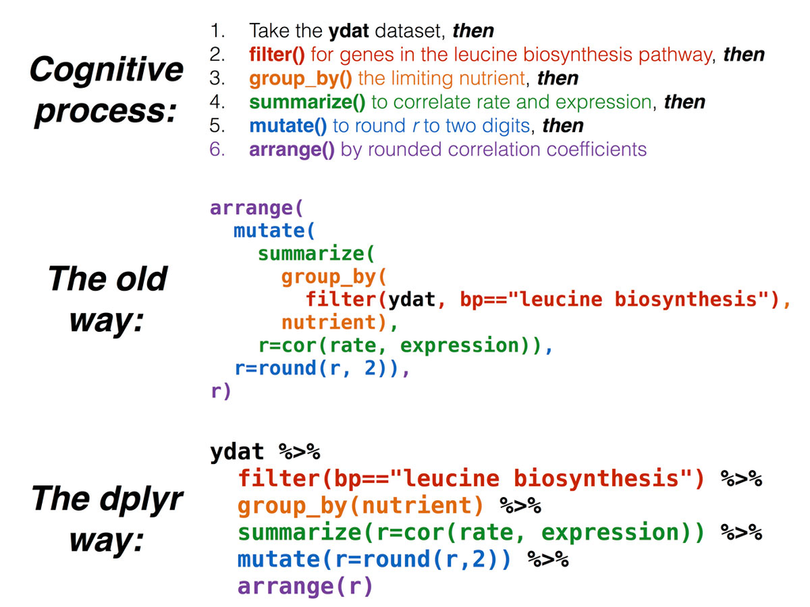

**Example:** group the cotton data set by year and output the mean yield for each year.

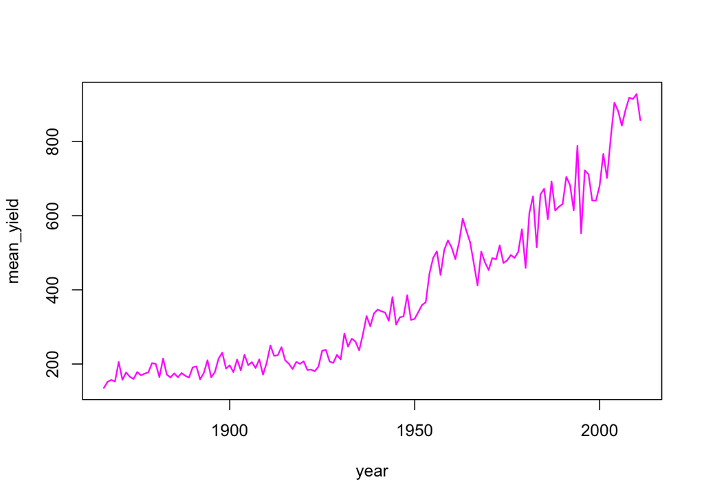

```r
cotton_annual_mean <- group_by(nass_cotton, year) %>% summarise(mean_yield = mean(yield, na.rm = T))
with(cotton_annual_mean, plot(year, mean_yield, type = "l", col = "magenta", lwd = 1.5))
```

```r
corn_highest_yielders <- nass_corn %>% mutate(HI = yield/acres) %>%
  group_by(year) %>% slice(which.max(HI)) %>%
  select(year, state, yield, HI) %>% mutate(state = as.character(state))

corn_highest_yielders %>% group_by(state) %>% tally(sort = T)
```

```
## # A tibble: 11 x 2
##    state            n
##    <chr>        <int>
##  1 Montana         27
##  2 Arizona         25
##  3 Nevada          24
##  4 Oregon          20
##  5 Rhode Island    20
##  6 Vermont         12
##  7 Utah             8
##  8 Maine            5
##  9 Wyoming          3
## 10 Connecticut      1
## 11 Idaho            1
```

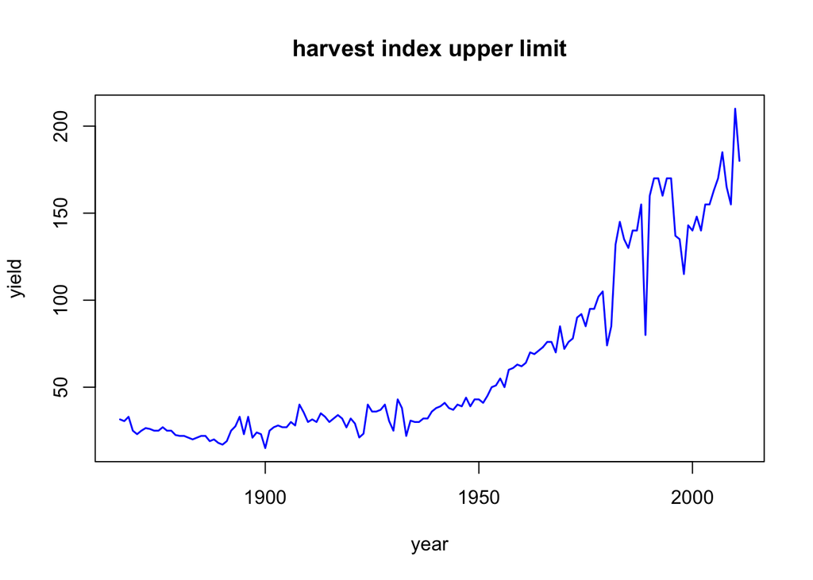

```r
with(corn_highest_yielders, plot(year, yield, type = "l", col = "blue", lwd = 1.5, main = "harvest index upper limit"))
```

### Free training resources

- R for data science
- RStudio Cheat sheets
- Package documentation
- Tutorials put together by package authors:

```
vignette("dplyr")
```

### Other useful functions

| Package | Function | Purpose |
| --- | --- | --- |
| dplyr | `pull()` | extracts a single column and returns a vector |
| dplyr | `n()` | counts observations |
| dplyr | `n_distinct()` | counts the number of unique observations |
| dplyr | `distinct()` | keeps only unique observations |
| dplyr | `starts_with()` | used within `select()`, for selecting columns that start with a specific string of characters |
| tidyr | `drop_na()` | remove rows with any missing data |
| tidyr | `fill()` | fills in missing values with whatever occurs before it (column-wise). Its behavior is dependent on row order |
| tidyr | `replace_na()` | replace missing values with a user-defined value (only when is.na(x) evaluates as “TRUE”) |

### *Brought to you by…STATISTICAL PROGRAMS!!*

*Statistical consulting to support the College of Agriculture and Life Sciences.*

**Bill Price**, Director, bprice@uidaho.edu, AgSci307

**Julia Piaskowski**, jpiaskowski@uidaho.edu, AgSci 305

[figure not shown]

[figure not shown]

**Live shots of your statistical consultants in action**